# Project_EDA

Niharika

February 2, 2018

# Wine Quality Analysis by Niharika J. Shah

# Introduction

The tidy data set on wine quality categorized from 3 to 9 is provided by Udacity. It has 4898 set of observation with 13 variables. Each variable except the varaible X which is sequence number for the dataset will be anlayzed in order to get to more about wine quality and their relationship with each other for the best quality wine.

# Univariate Plots Section

```
## 'data.frame':    4898 obs. of  13 variables:
##  $ X                   : int  1 2 3 4 5 6 7 8 9 10 ...
##  $ fixed.acidity       : num  7 6.3 8.1 7.2 7.2 8.1 6.2 7 6.3 8.1 ...
##  $ volatile.acidity    : num  0.27 0.3 0.28 0.23 0.23 0.28 0.32 0.27 0.3 0.22 ...
##  $ citric.acid         : num  0.36 0.34 0.4 0.32 0.32 0.4 0.16 0.36 0.34 0.43 ...
##  $ residual.sugar      : num  20.7 1.6 6.9 8.5 8.5 6.9 7 20.7 1.6 1.5 ...
##  $ chlorides           : num  0.045 0.049 0.05 0.058 0.058 0.05 0.045 0.045 0.049 0.044 ...
##  $ free.sulfur.dioxide : num  45 14 30 47 47 30 30 45 14 28 ...
##  $ total.sulfur.dioxide: num  170 132 97 186 186 97 136 170 132 129 ...
##  $ density             : num  1.001 0.994 0.995 0.996 0.996 ...
##  $ pH                  : num  3 3.3 3.26 3.19 3.19 3.26 3.18 3 3.3 3.22 ...
##  $ sulphates           : num  0.45 0.49 0.44 0.4 0.4 0.44 0.47 0.45 0.49 0.45 ...
##  $ alcohol             : num  8.8 9.5 10.1 9.9 9.9 10.1 9.6 8.8 9.5 11 ...
##  $ quality             : int  6 6 6 6 6 6 6 6 6 6 ...
```

```
##   X fixed.acidity volatile.acidity citric.acid residual.sugar chlorides
## 1 1           7.0             0.27        0.36           20.7     0.045
## 2 2           6.3             0.30        0.34            1.6     0.049
## 3 3           8.1             0.28        0.40            6.9     0.050
## 4 4           7.2             0.23        0.32            8.5     0.058
## 5 5           7.2             0.23        0.32            8.5     0.058
## 6 6           8.1             0.28        0.40            6.9     0.050
##   free.sulfur.dioxide total.sulfur.dioxide density   pH sulphates alcohol
## 1                  45                  170  1.0010 3.00      0.45     8.8
## 2                  14                  132  0.9940 3.30      0.49     9.5
## 3                  30                   97  0.9951 3.26      0.44    10.1
## 4                  47                  186  0.9956 3.19      0.40     9.9
## 5                  47                  186  0.9956 3.19      0.40     9.9
## 6                  30                   97  0.9951 3.26      0.44    10.1
##   quality
## 1       6
## 2       6
## 3       6
## 4       6
## 5       6
## 6       6
```

### Histograms for all variables

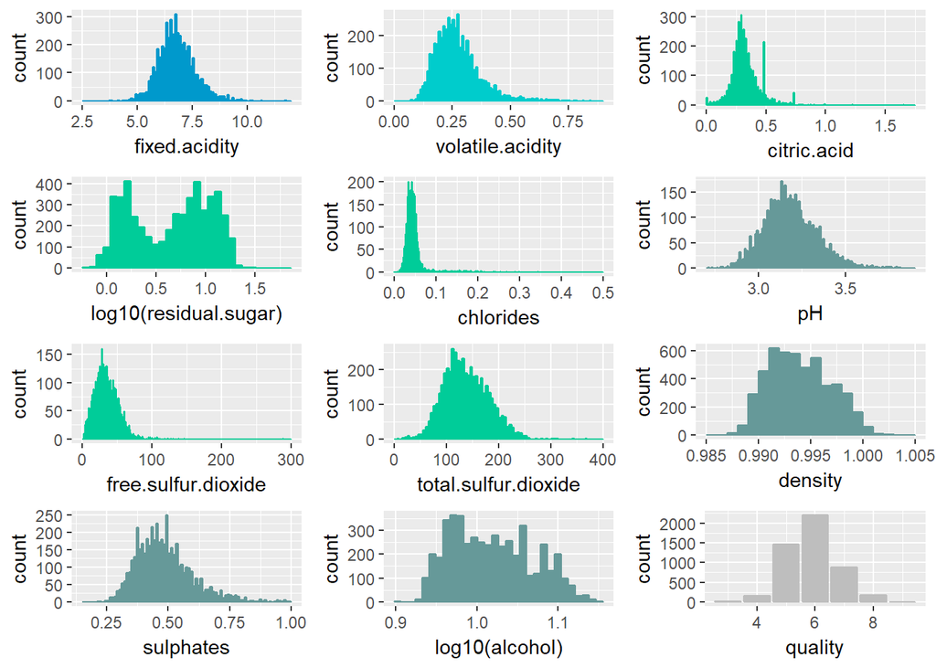

### Creating two new varibles sulfurRatio and acidityRatio

```
##             citric.acid residual.sugar   chlorides     density
## nobs        4898.000000    4898.000000 4898.000000 4898.000000
## NAs            0.000000       0.000000    0.000000    0.000000
## Minimum        0.000000       0.600000    0.009000    0.987110
## Maximum        1.660000      65.800000    0.346000    1.038980
## 1. Quartile    0.270000       1.700000    0.036000    0.991723
## 3. Quartile    0.390000       9.900000    0.050000    0.996100
## Mean           0.334192       6.391415    0.045772    0.994027
## Median         0.320000       5.200000    0.043000    0.993740
## Sum         1636.870000   31305.150000  224.193000 4868.746090
## SE Mean        0.001729       0.072473    0.000312    0.000043
## LCL Mean       0.330801       6.249336    0.045160    0.993944
## UCL Mean       0.337582       6.533494    0.046384    0.994111
## Variance       0.014646      25.725770    0.000477    0.000009
## Stdev          0.121020       5.072058    0.021848    0.002991
## Skewness       1.281135       1.076434    5.020254    0.977174
## Kurtosis       6.163631       3.462415   37.508493    9.777368
##                       pH   sulphates      alcohol      quality sulfurRatio
## nobs         4898.000000 4898.000000  4898.000000  4898.000000 4898.000000
## NAs             0.000000    0.000000     0.000000     0.000000    0.000000
## Minimum         2.720000    0.220000     8.000000     3.000000    0.023622
## Maximum         3.820000    1.080000    14.200000     9.000000    0.710526
## 1. Quartile     3.090000    0.410000     9.500000     5.000000    0.190935
## 3. Quartile     3.280000    0.550000    11.400000     6.000000    0.315789
## Mean            3.188267    0.489847    10.514267     5.877909    0.255577
## Median          3.180000    0.470000    10.400000     6.000000    0.253677
## Sum         15616.130000 2399.270000 51498.880000 28790.000000 1251.815926
## SE Mean         0.002158    0.001631     0.017584     0.012655    0.001343
## LCL Mean        3.184037    0.486650    10.479795     5.853101    0.252944
## UCL Mean        3.192496    0.493044    10.548739     5.902718    0.258210
## Variance        0.022801    0.013025     1.514427     0.784356    0.008836
## Stdev           0.151001    0.114126     1.230621     0.885639    0.094000
## Skewness        0.457502    0.976595     0.487044     0.155701    0.381027
## Kurtosis        0.527568    1.586208    -0.699877     0.213767    0.561985
##             acidityRatio
## nobs         4898.000000
## NAs             0.000000
## Minimum         0.011111
## Maximum         0.180328
## 1. Quartile     0.030303
## 3. Quartile     0.048479
## Mean            0.041262
## Median          0.038356
## Sum           202.100199
## SE Mean         0.000231
## LCL Mean        0.040810
## UCL Mean        0.041714
## Variance        0.000261
## Stdev           0.016141
## Skewness        1.645903
## Kurtosis        5.459204
```

### Citric Acid:

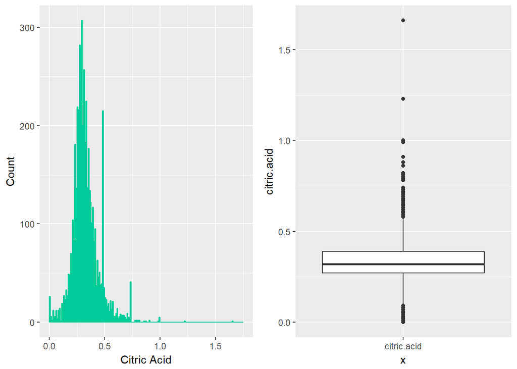

```
##    Min. 1st Qu.  Median    Mean 3rd Qu.    Max.
##  0.0000  0.2700  0.3200  0.3342  0.3900  1.6600
```

Roughly Citric Acid histogram is normally distributed I see long tail, which is  
also indicated in boxplot showing outliers. The range for 1st quartile and 3rd  
quartile is from .27 to .39 whereas max is at 1.66

### Residual Sugar:

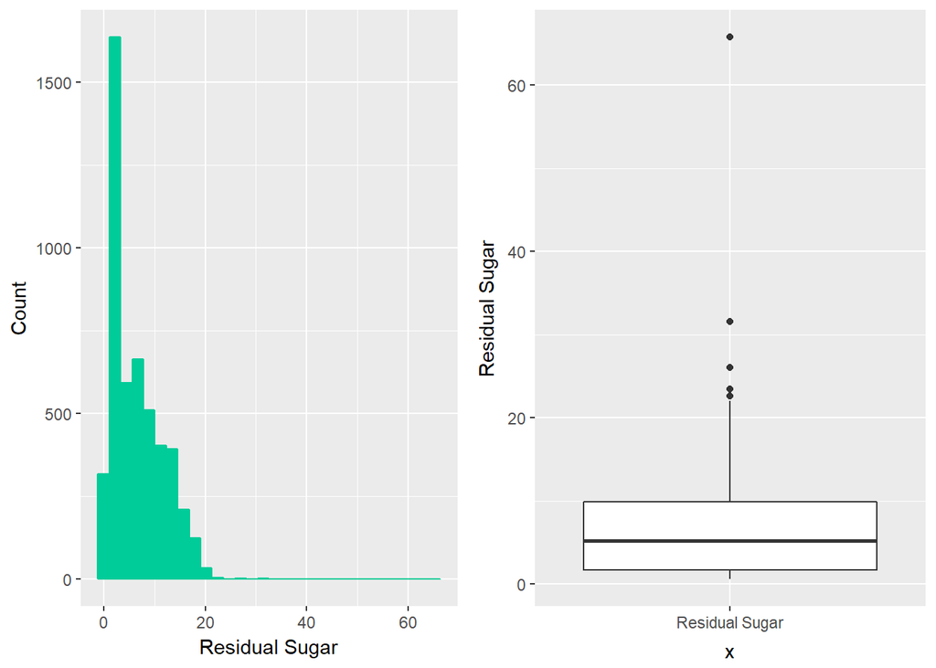

```
##    Min. 1st Qu.  Median    Mean 3rd Qu.    Max.
##   0.600   1.700   5.200   6.391   9.900  65.800
```

The histogram for residual sugar has long tail which can be explained from  
boxplot that there are outliers, It will be interesting to know more about  
this variable when I will explore in bivariate plots.

### Chlorides:

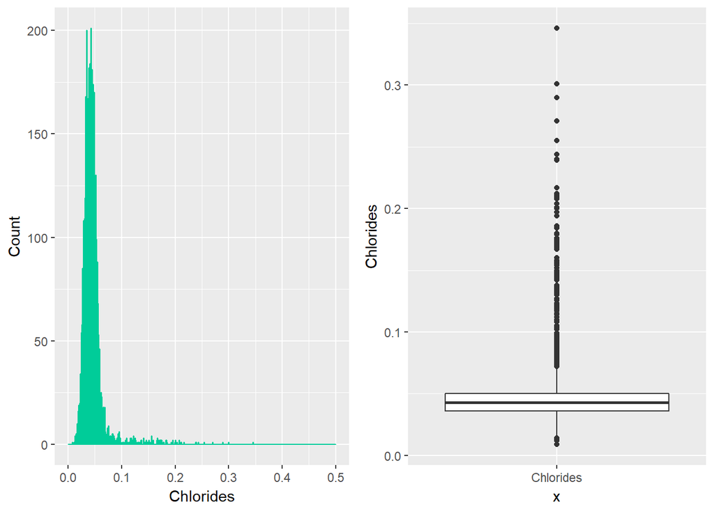

```
##    Min. 1st Qu.  Median    Mean 3rd Qu.    Max.
## 0.00900 0.03600 0.04300 0.04577 0.05000 0.34600
```

Chlorides histogram looks roughly normal as well however, boxplot indicates  
that there are many outliers, also can be explained with long tail in histogram.

### Density:

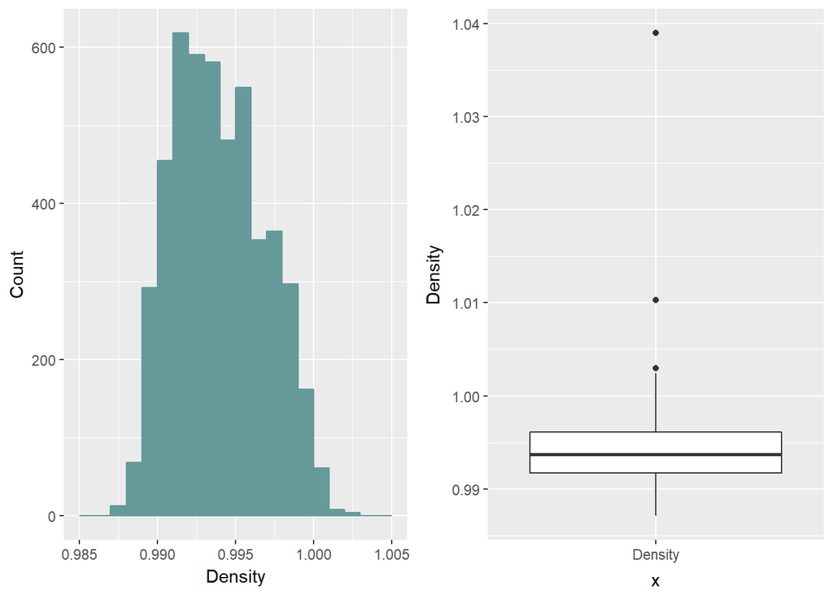

```
##    Min. 1st Qu.  Median    Mean 3rd Qu.    Max.
##  0.9871  0.9917  0.9937  0.9940  0.9961  1.0390
```

Density histogram is looks normal and boxplot shows just three outliers.I would  
like to explore if these outliers have any corelation with other variables.

### pH Value:

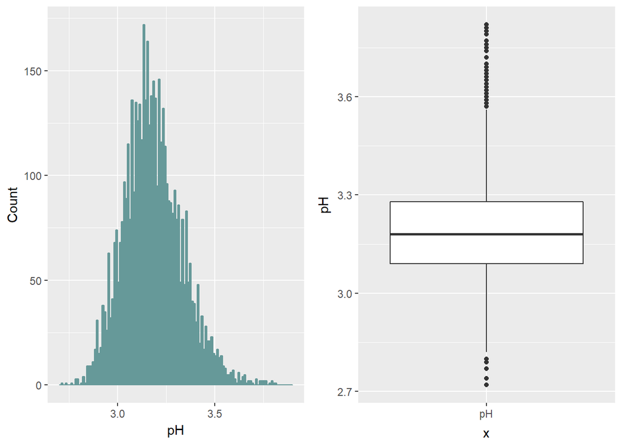

```
##    Min. 1st Qu.  Median    Mean 3rd Qu.    Max.
##   2.720   3.090   3.180   3.188   3.280   3.820
```

### Sulphates:

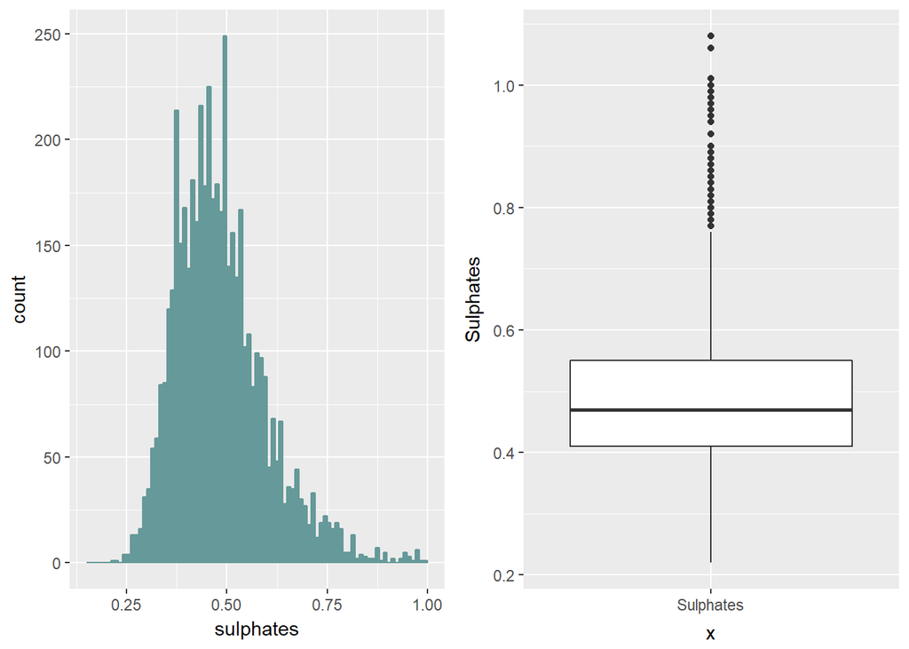

```
##    Min. 1st Qu.  Median    Mean 3rd Qu.    Max.
##  0.2200  0.4100  0.4700  0.4898  0.5500  1.0800
```

The histogram for sulphates is roughly normal.

### Alcohol:

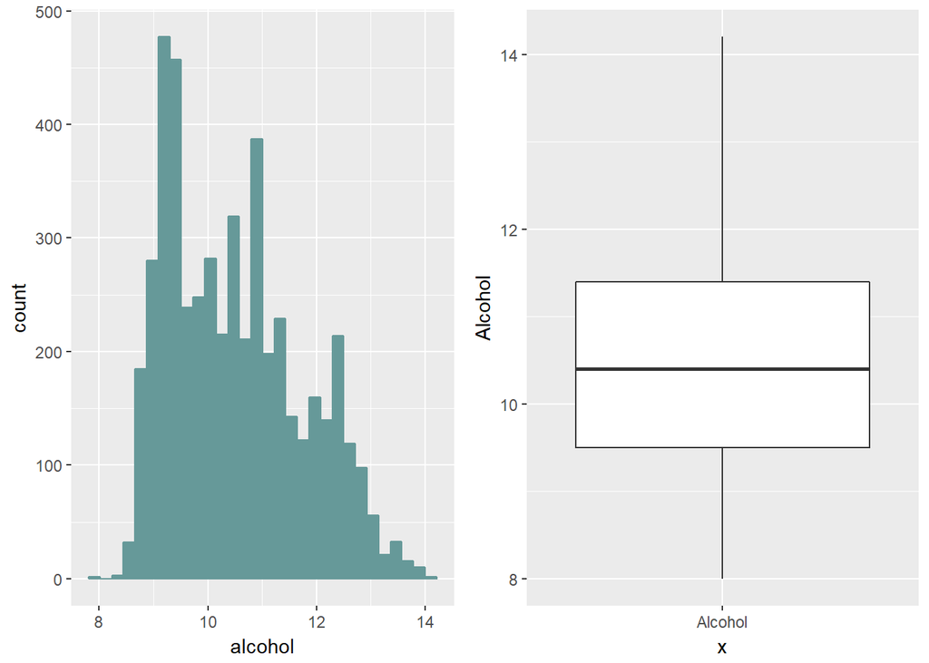

```
##    Min. 1st Qu.  Median    Mean 3rd Qu.    Max.
##    8.00    9.50   10.40   10.51   11.40   14.20
```

It would be interesting to know correlation between alcohol and quality, and  
how other variable correlate with alcohol as alcohol is one of the main  
variable which defines wine quality.

### Quality:

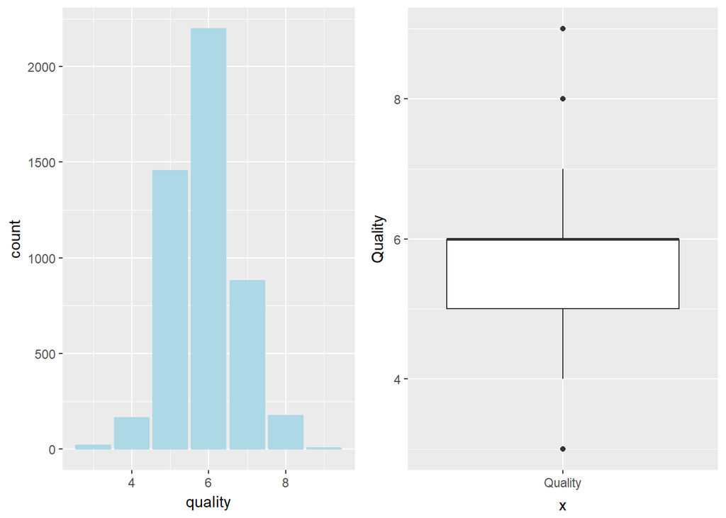

```
##    Min. 1st Qu.  Median    Mean 3rd Qu.    Max.
##   3.000   5.000   6.000   5.878   6.000   9.000
```

Quality is normally distributed

### Sulfur Ratio:

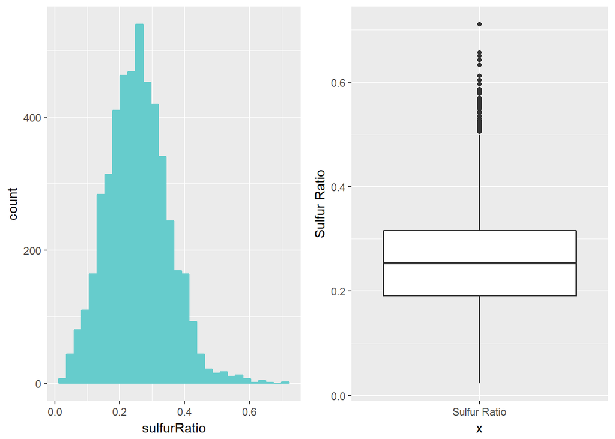

```
##    Min. 1st Qu.  Median    Mean 3rd Qu.    Max.
## 0.02362 0.19093 0.25368 0.25558 0.31579 0.71053
```

Sulfur Ratio also looks normally distributed

### Acidity Ratio:

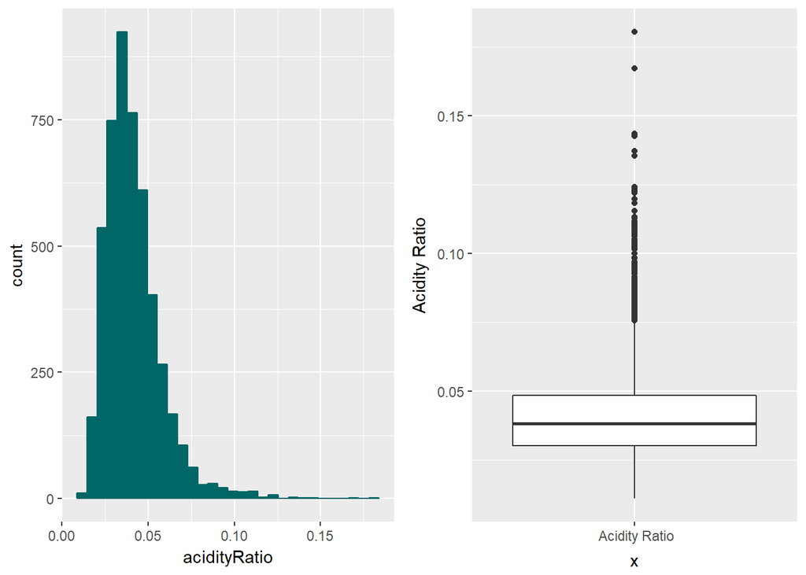

```
##    Min. 1st Qu.  Median    Mean 3rd Qu.    Max.
## 0.01111 0.03030 0.03836 0.04126 0.04848 0.18033
```

Acidity Ratio has long tail on right side however it is also roughly normally  
distributed.

# Univariate Analysis

### What is the structure of your dataset?

There are 4898 obs. of 13 variables in the dataset. X : num fixed.acidity : num  
volatile.acidity : num  
citric.acid : num  
residual.sugar : num  
chlorides : num  
free.sulfur.dioxide : num  
total.sulfur.dioxide: num density : num  
pH : num sulphates : num alcohol : num  
quality : 3,4,5,6,7,8,9 as categorical variable

Most number of white wines are of quality level 6 in this dataset.

### What is/are the main feature(s) of interest in your dataset?

Main feature of the datasets include how the quality and alcohol content of  
wine. I would like to see how these two varaibles correlated with other varaible.

### What other features in the dataset do you think will help support your investigation into your feature(s) of interest?

pH levels, residual.sugar levels, acidity levels. I would like to know if  
they have any affect on quality and alcohol.

### Did you create any new variables from existing variables in the dataset?

I created two new ratio variables for acidity and sulphur.dioxide First variable I created is Ratio between volatile acidity and fixed acidity Second variable is Ratio between free.sulfur.dioxide and total.sulfur.dioxide. After looking at their individual histogram both acidity and sulphur.dioxide  
looked similar, therefore I beleive these two ratio would give better conclusions.

Hence I decided to drop individal acidity and sulphur.dioxide variables and  
worked with ratios instead.

### Of the features you investigated, were there any unusual distributions? Did you perform any operations on the data to tidy, adjust, or change the form of the data? If so, why did you do this?

# Bivariate Plots Section

### Correlation Table

| corTable | citric.acid | residual.sugar | chlorides | density | pH | sulphates | alcohol | quality | sulfurRatio | acidityRatio |
| --- | --- | --- | --- | --- | --- | --- | --- | --- | --- | --- |
| citric.acid | 1 | 0.09 | 0.11 | 0.15 | -0.16 | 0.06 | -0.08 | -0.01 | 0.02 | -0.25 |
| residual.sugar | 0.09 | 1 | 0.09 | 0.84 | -0.19 | -0.03 | -0.45 | -0.1 | 0.05 | 0.02 |
| chlorides | 0.11 | 0.09 | 1 | 0.26 | -0.09 | 0.02 | -0.36 | -0.21 | -0.03 | 0.04 |
| density | 0.15 | 0.84 | 0.26 | 1 | -0.09 | 0.07 | -0.78 | -0.31 | -0.07 | -0.08 |
| pH | -0.16 | -0.19 | -0.09 | -0.09 | 1 | 0.16 | 0.12 | 0.1 | 0 | 0.11 |
| sulphates | 0.06 | -0.03 | 0.02 | 0.07 | 0.16 | 1 | -0.02 | 0.05 | -0.02 | -0.03 |
| alcohol | -0.08 | -0.45 | -0.36 | -0.78 | 0.12 | -0.02 | 1 | 0.44 | 0.06 | 0.11 |
| quality | -0.01 | -0.1 | -0.21 | -0.31 | 0.1 | 0.05 | 0.44 | 1 | 0.2 | -0.14 |
| sulfurRatio | 0.02 | 0.05 | -0.03 | -0.07 | 0 | -0.02 | 0.06 | 0.2 | 1 | -0.14 |
| acidityRatio | -0.25 | 0.02 | 0.04 | -0.08 | 0.11 | -0.03 | 0.11 | -0.14 | -0.14 | 1 |

We can divide wine categories into three categories: Poor (3-4), Medium(5-6), and Best(7-8-9) for further bi-variate and multi variate analysis

### Boxplot for Citric Acid for Quality Category

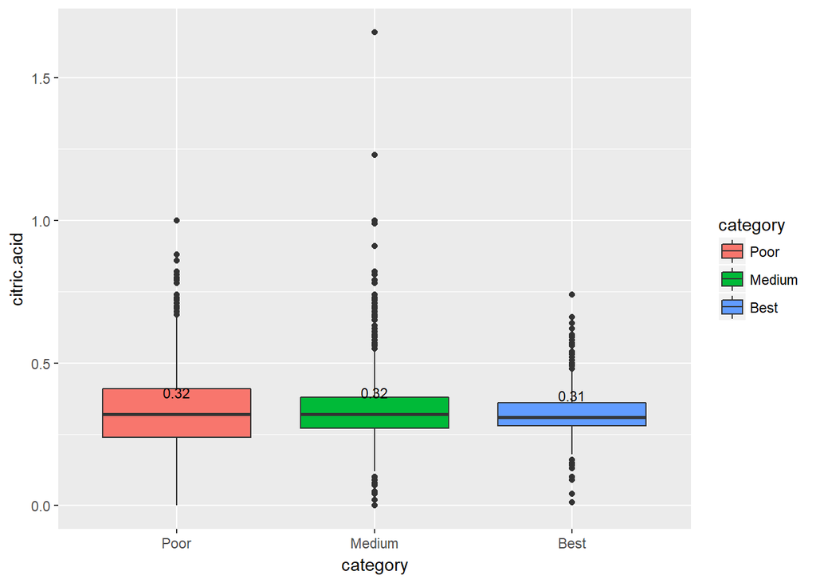

```
## [1] "Mean: "
```

```
## [1] 0.33 0.34 0.33
```

Best quality wines have lowest levels of citric acid however there is no significant difference among wine categories.

### Boxplot for Residual Sugar for Quality Category

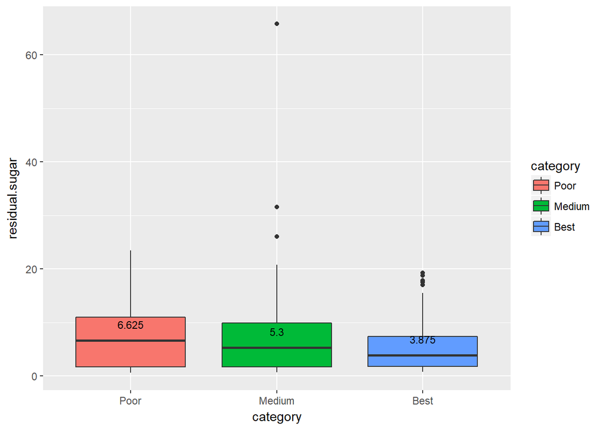

```
## [1] "Mean: "
```

```
## [1] 7.05 6.44 5.26
```

Best quality wines have lowest level of residual sugars which can be exlplained as residual sugars turn into alcohol during fermentation process, the less the sugar, the more alcohol content. However, I see some outliers in best quality wines as well, that’s explains mean and median both have significant difference.

### Boxplot for Chlorides for Quality Category

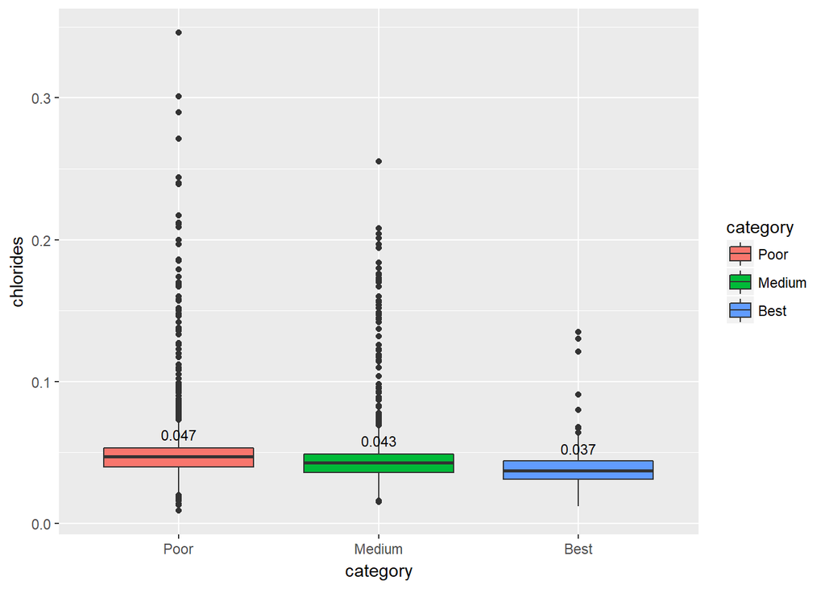

```
## [1] "Mean: "
```

```
## [1] 0.051 0.045 0.038
```

Chloride levels are lowest in best quality wines. Mean and Median are very close for best quality wines which explains less number of outliers.

### Boxplot for Density for Quality Category

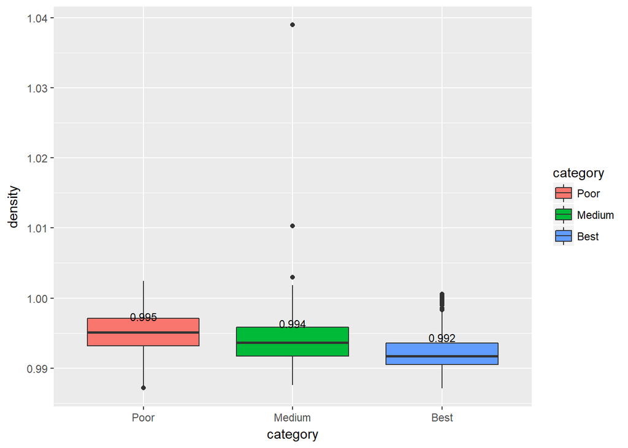

```
## [1] "Mean: "
```

```
## [1] 0.995 0.994 0.992
```

Density is also has lowest value in best quality wine, which can be explained with alcohol content in any wine. More alcohol content results in less density. We can also see that all categories of wines have less number of outliers as for all of them mean and median both are very close.

### Boxplot for pH value for Quality Category

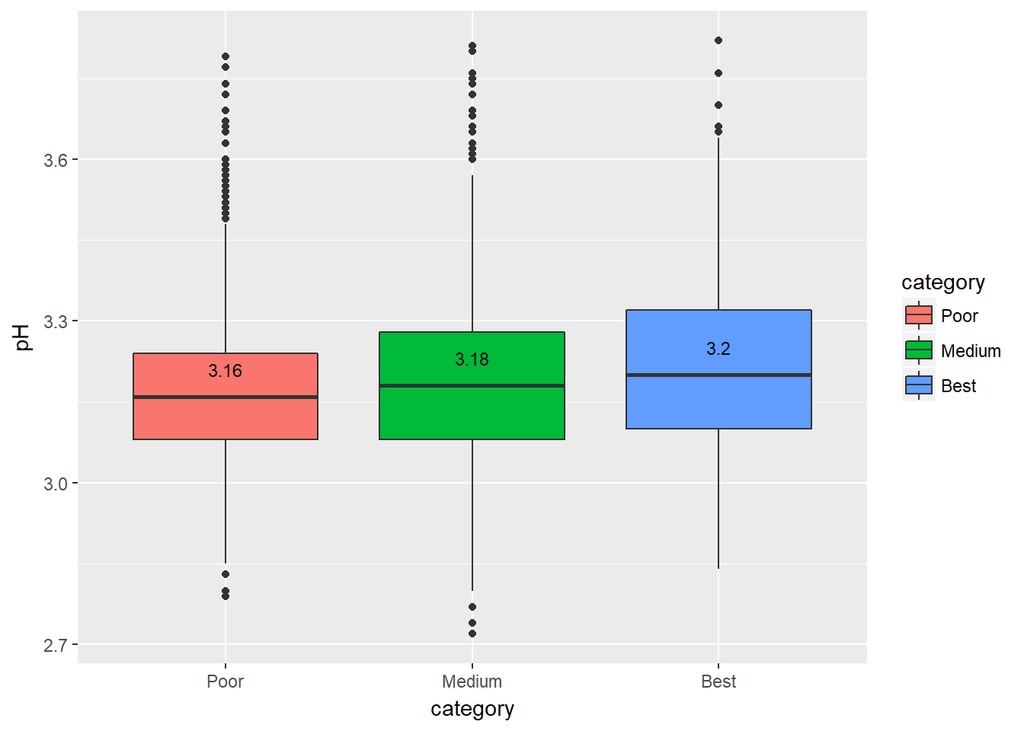

```
## [1] "Mean: "
```

```
## [1] 3.170 3.189 3.215
```

pH values are highest in best quality wines hence we can say that best quality wines are less acidic than other categories.

### Boxplot for Sulphates for Quality Category

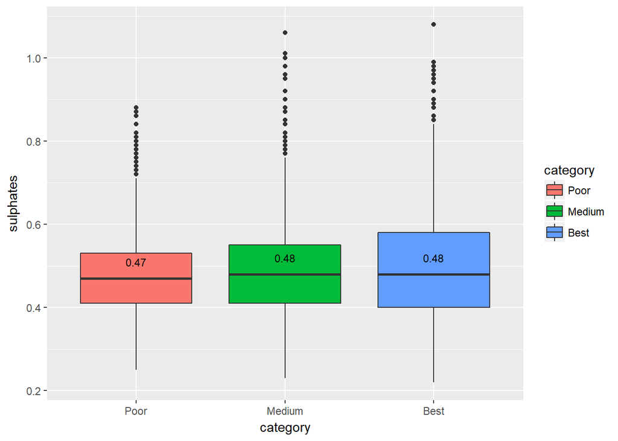

```
## [1] "Mean: "
```

```
## [1] 0.482 0.491 0.500
```

I don’t see any difference in sulphates levels among three categories. Medium and Best quality wines both have same levels, hence we can not conclude anyhting based on sulphates levels in any wine.

### Boxplot for Alcohol for Quality Category

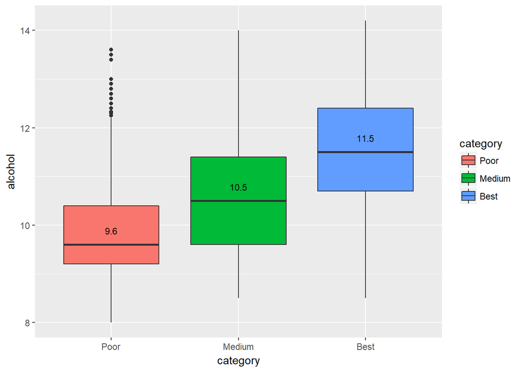

```
## [1] "Mean: "
```

```
## [1]  9.850 10.575 11.416
```

I can see significant difference among three catgories for alcohol content. Best quality wine certainly have more alcohol content.Additionally, there are no outliers in medium and best quality wines for alcohol content.However, poor quality wine show many outliers.

### Boxplot for Sulfur Ratio for Quality Category

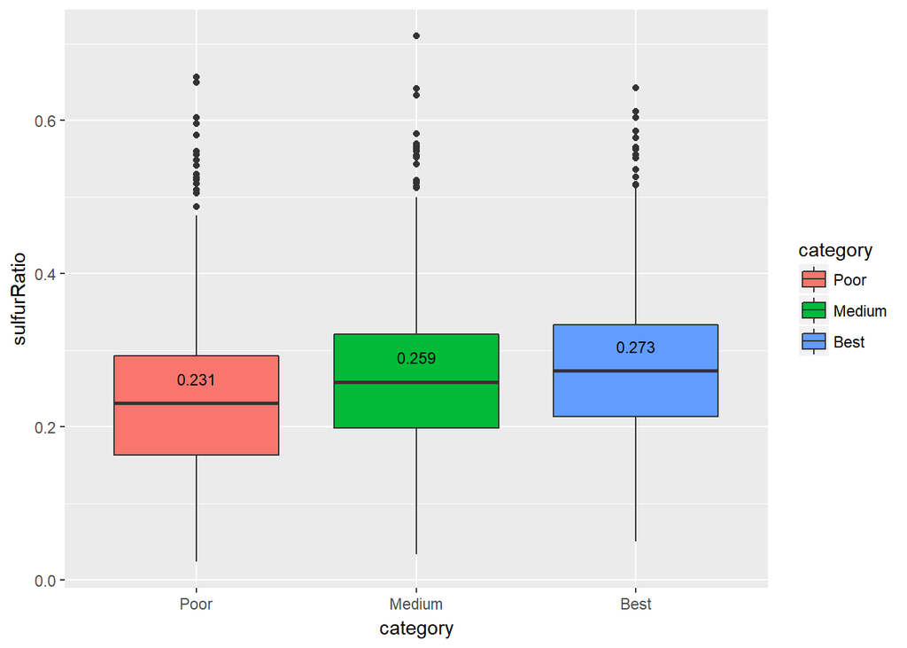

```
## [1] "Mean: "
```

```
## [1] 0.232 0.262 0.278
```

Sulfur Ratio is highest in Best quality wines.

### Boxplot for Acidity Ratio for Quality Category

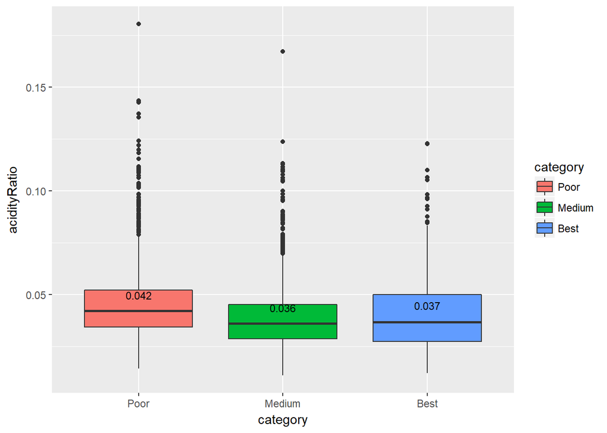

```
## [1] "Mean: "
```

```
## [1] 0.045 0.039 0.040
```

Acidity Ratio doesn’t give any clear picture among wine categories for better or worse wines.

### Alcohol vs. Density:

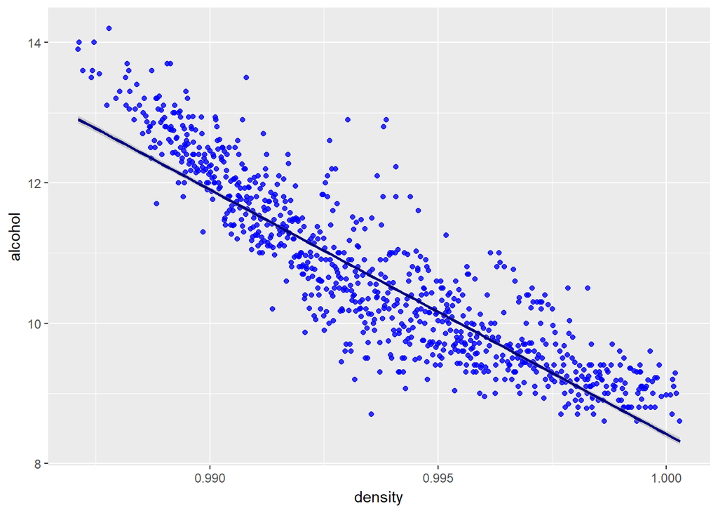

I can see clear correlation between Alcohol and Density. As with more alcohol content in a wine density decreases, which I also observed in correlation table with high correlation coefficient -.78

### Alcohol vs. Residual Sugar

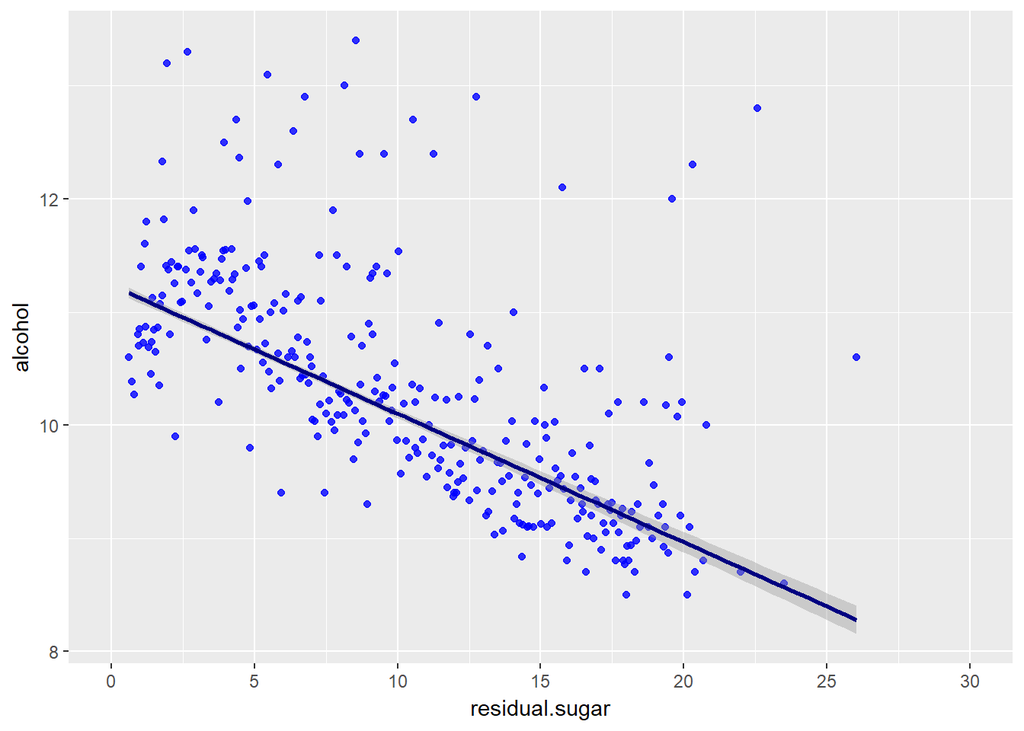

As obsereved in correlation table with coeeficient as -.45 which is not very strong however not very weak as well. It would be interesting to see how these two variables behave in multivariate analysis with quality category.

### pH vs. Acidity Ratio

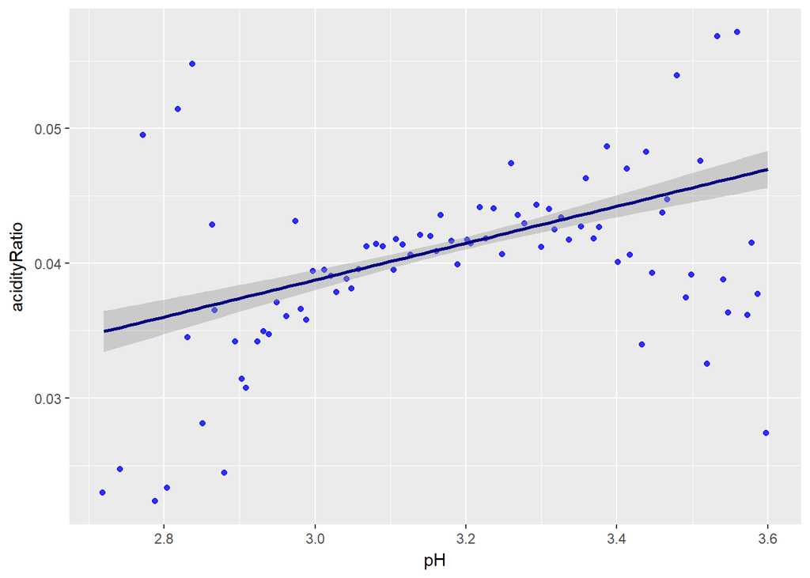

I was looking for some correlation between pH and Acidity Ratio given pH values increases with acidity levels. However, I did not find any correlation. These two varaibles can also be explored futher based on quality category if their behaviour is different among quality category.

### pH vs. Citric Acid

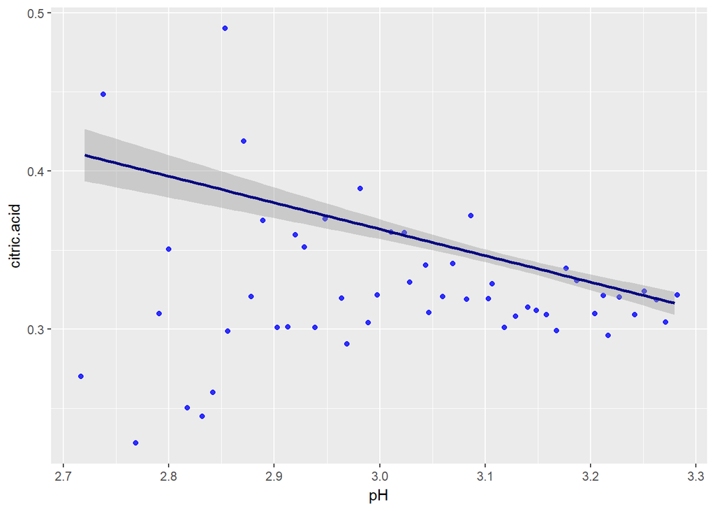

I don’t see any correlation between pH and citric acid.

# Bivariate Analysis

### Talk about some of the relationships you observed in this part of the investigation. How did the feature(s) of interest vary with other features in the dataset?

- Correlation table indicates that Residual Sugar and Density are strongly  
  correlated with correlation coefficient .84
- Density and Alcohol are negatively correlated with correlation  
  coefficient -.78
- pH correlation with acidityRatio is low with correlaion coefficient .11
- Citric acid across quality varies and doesn’t indicate any co-realtion between  
  these two variables. It stays close .32 for quality category 4,5,8 but for  
  quality category 3 and 9 it is .34 and .36 respectively. If I assume 3 as  
  worst quality and 9 as best it doesn’t indicate clearly that with quality  
  it’s increasing or decreasing. [Many winemakers add citric acid to acidify wine to bring flavors that are too basic.](http://www.calwineries.com/learn/wine-chemistry/wine-acids/citric-acid)/ It is an intermediate in the TCA cycle, which provides molecular energy for  
  cellular function. However, its role in wine is far less important.
- Median residual sugar is least in category 9 which is 2.2,whereas highest in  
  category 5 which is 7. [In sweet wine, the yeasts are killed before all the sugar is used, leaving residual sugars](http://www.calwineries.com/learn/wine-chemistry/sugar-in-wine) During  
  fermentation process yeast consumes sugar for energy. If it consumes all of the  
  sugars it falls into dry wine category. Additionally, sugar consumption by yeast also  
  yeilds alcohol. Hence we can see there is negative correlation between residual  
  sugar and alcohol. The less the sugar, the more alcohol content in a wine.  
  However, this correlation between these is not very strong.

From above description we can say category 9 is more towards a dry wine whereas  
category 5 is a sweet wine because of highest amount of residual sugars.

- Median values for Chlorides across category from 3 to 9 are in general in  
  decreasing order. This indicates that this variable needs to be explored  
  more with other varaibles as well.
- Density defines, presence of water which depends on percentage of alcohol and  
  sugar. Here in above boxplots density is peaks for quality category 5. However,  
  it is in decreasing order from left to right indicating that from quality  
  category 3 to 9 presence of water in decreasing. Density and residual sugar are strogly correlated which can be explained here if  
  we have less residual sugars, an increase in alcohol content, hence decreases  
  the density of a wine.
- The higher the pH, the lower the acidity, and the lower the pH, the higher the  
  acidity. Boxplots here show that pH value are higest for quality 9 which is in  
  general is in increasing order from left to right.
- Sulphates don’t seem to have any linear relationship amongs wine categories.
- Alcohol content in a wine found is natural result of yeast fermentation.During  
  the winemaking process all sugar converts to alcohol hence, thus the higher the  
  sugar in the fruit, the higher the alcohol content in a wine.Median values of  
  alcohol content dips from quality 3 to 5 and then it increases from 5 to 9. Correlation between density and alcohol is not perfectly linear however, they  
  are negatively correlated strongly with correlation coefficient -.78
- Median values for sulfur ratio dips at quality category 4 and then increases  
  from 5 to 8. sulfur dioxide prevents oxidization and maintains fresh taste of  
  a wine. Here, we can see that it is higest in qaulity 8 wine.
- Median values for acidityRatio across quality is least in quality category 9  
  and most in quality category 4. It indicates that fixed acidity is most in category 9 whereas volatile acidity is most in category 4.

# Multivariate Plots Section

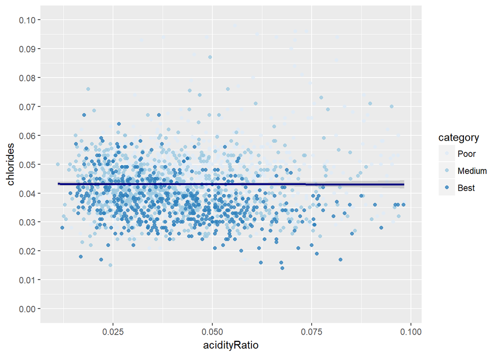

```
##
##  Pearson's product-moment correlation
##
## data:  wineQualityWhitesNew$acidityRatio and wineQualityWhitesNew$chlorides
## t = 3.1223, df = 4896, p-value = 0.001805
## alternative hypothesis: true correlation is not equal to 0
## 95 percent confidence interval:
##  0.01659216 0.07249386
## sample estimates:
##        cor
## 0.04457791
```

Chlorides are low in most best quality wines, however acidity ratio levels doesn’t show any patterns with respect to chlorides for any wines.

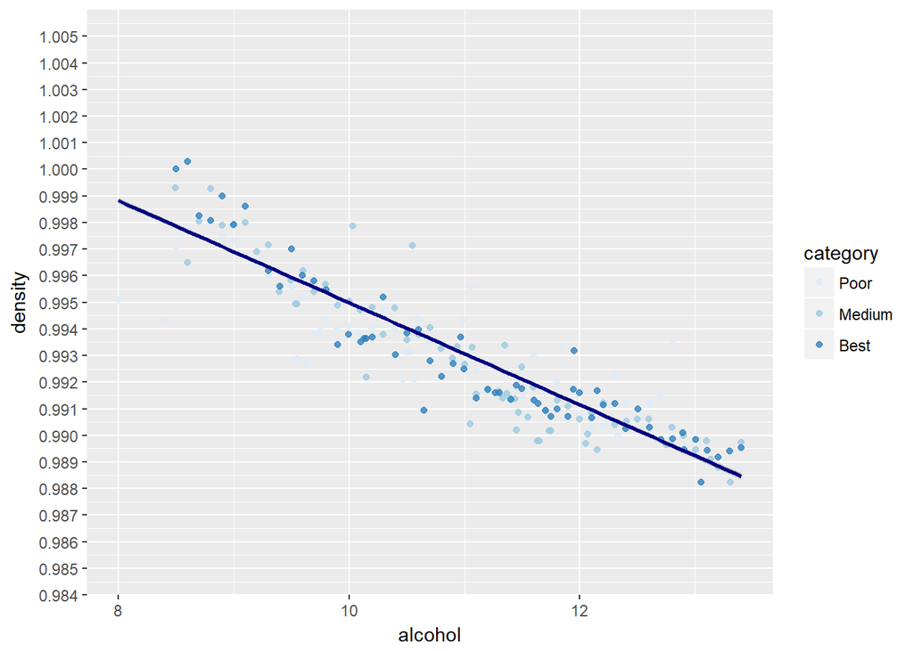

```
##
##  Pearson's product-moment correlation
##
## data:  wineQualityWhitesNew$alcohol and wineQualityWhitesNew$density
## t = -87.255, df = 4896, p-value < 2.2e-16
## alternative hypothesis: true correlation is not equal to 0
## 95 percent confidence interval:
##  -0.7908646 -0.7689315
## sample estimates:
##        cor
## -0.7801376
```

Density and Alcohol show a clear pattern across all types of wines. Most best quality wines fall under low density and high alcohol content.

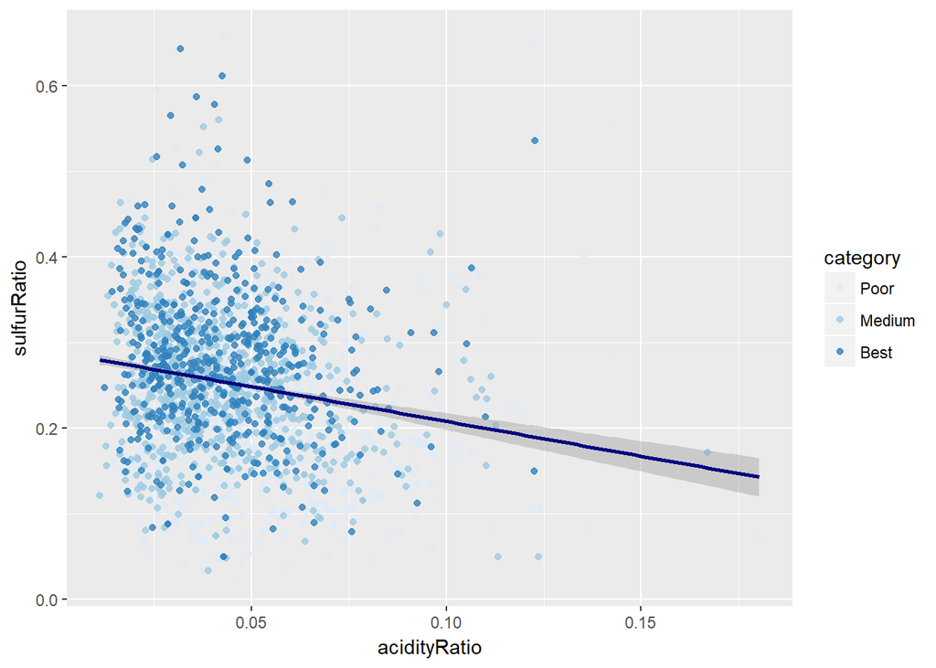

```
##
##  Pearson's product-moment correlation
##
## data:  wineQualityWhitesNew$acidityRatio and wineQualityWhitesNew$sulfurRatio
## t = -9.8311, df = 4896, p-value < 2.2e-16
## alternative hypothesis: true correlation is not equal to 0
## 95 percent confidence interval:
##  -0.1664927 -0.1115633
## sample estimates:
##       cor
## -0.139135
```

Most best quality wines fall under low acidity ratio and high sulfur ratio.However, there is a weak correlation among wine’s acidity ratio and sulfur ratio.

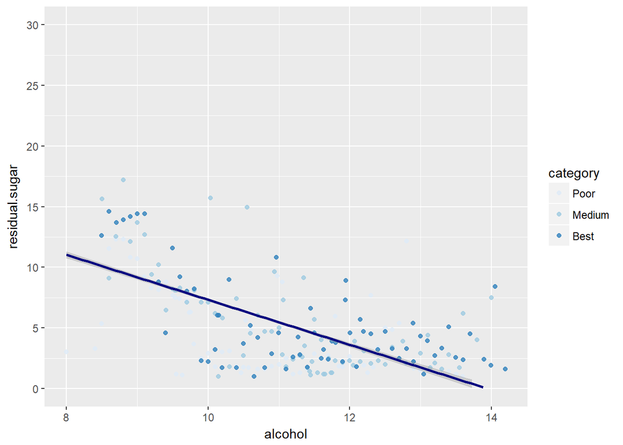

```
##
##  Pearson's product-moment correlation
##
## data:  wineQualityWhitesNew$alcohol and wineQualityWhitesNew$residual.sugar
## t = -35.321, df = 4896, p-value < 2.2e-16
## alternative hypothesis: true correlation is not equal to 0
## 95 percent confidence interval:
##  -0.4726723 -0.4280267
## sample estimates:
##        cor
## -0.4506312
```

We see a clear pattern between residual sugar and alcohol content in wines as well. Most best quality wines have less residual sugar and high alcohol content.

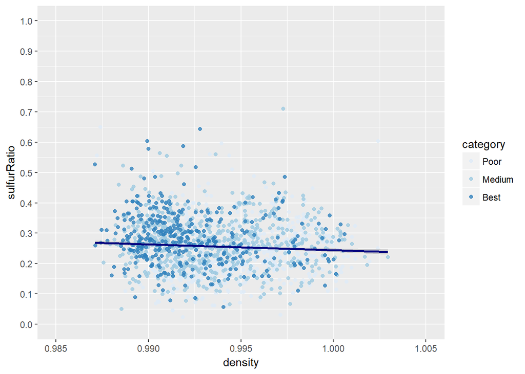

```
##
##  Pearson's product-moment correlation
##
## data:  wineQualityWhitesNew$density and wineQualityWhitesNew$sulfurRatio
## t = -4.5947, df = 4896, p-value = 4.442e-06
## alternative hypothesis: true correlation is not equal to 0
## 95 percent confidence interval:
##  -0.09335988 -0.03758727
## sample estimates:
##         cor
## -0.06552475
```

Most best quality wines have low density and high sulfur ratio, however, same cannot be said about medium and poor quality wines.

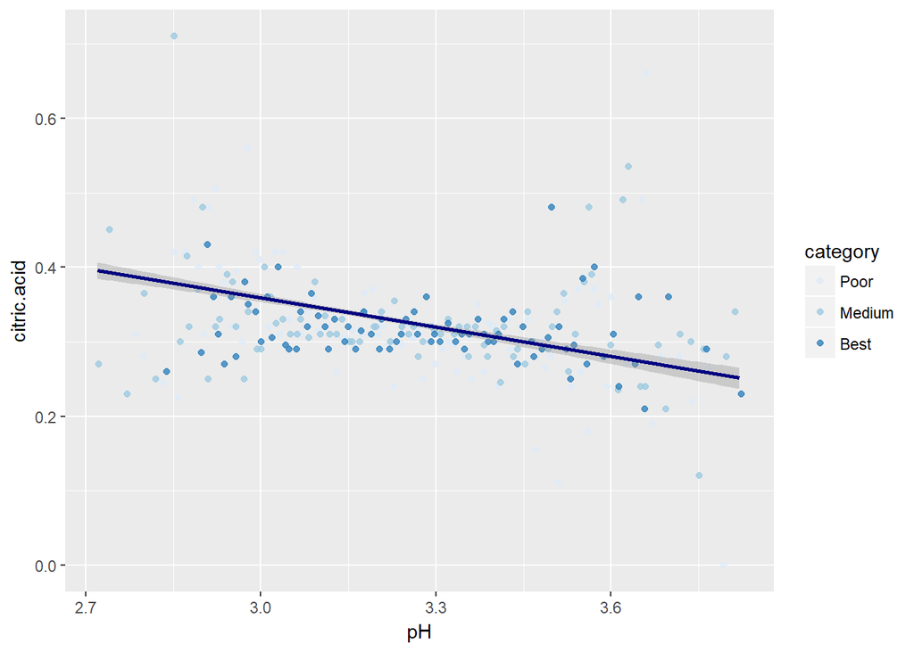

```
##
##  Pearson's product-moment correlation
##
## data:  wineQualityWhitesNew$pH and wineQualityWhitesNew$citric.acid
## t = -11.614, df = 4896, p-value < 2.2e-16
## alternative hypothesis: true correlation is not equal to 0
## 95 percent confidence interval:
##  -0.1908793 -0.1363671
## sample estimates:
##        cor
## -0.1637482
```

I was expecting some corealtion between pH and citric acid for best quality wines. However,I did not find any correlation for different categories of wines.

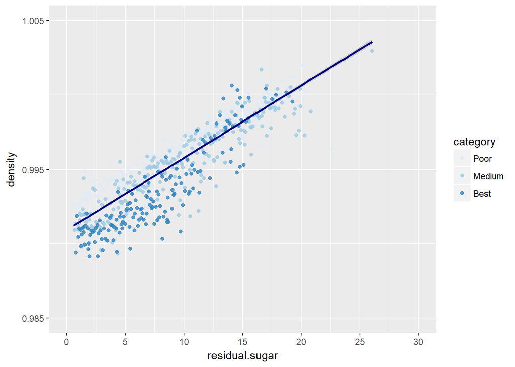

```
##
##  Pearson's product-moment correlation
##
## data:  wineQualityWhitesNew$residual.sugar and wineQualityWhitesNew$density
## t = 107.87, df = 4896, p-value < 2.2e-16
## alternative hypothesis: true correlation is not equal to 0
## 95 percent confidence interval:
##  0.8304732 0.8470698
## sample estimates:
##       cor
## 0.8389665
```

Most best quality wines falls under low density and low residual sugar. However, for medium and poor quality wines spread is towards high density and high residual sugars.